# Partnership duration

This section summarises the data on the age of extant main and persistent ties and calculates the mean durations given by the observed medians based on an exponential distribution. For these analyses, we use the combined reweighted WHPP and ART-Net samples.

## Main partnerships

This histogram below shows the distribution of main partnership ages in the re-weighted samples with an overlaid exponential distribution. The exponential distribution does not appear to be a great fit, but with current methods, assuming an exponential distribution is our best option (see [issue #29](https://github.com/statnet/WHAMP/issues/29)).

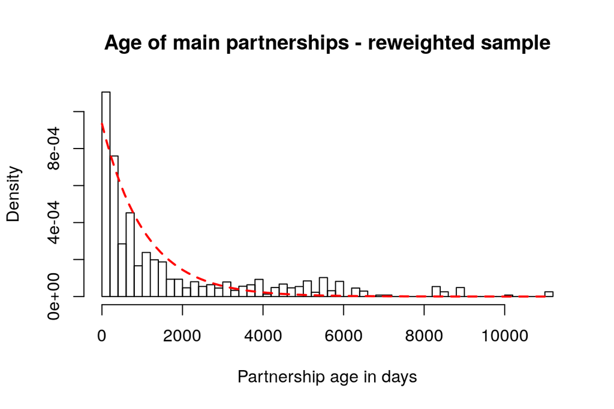

Assuming an exponential distribution, the mean duration of main partnerships given by the observed median duration of extant ties is shown in the table below.

| Observed median age in days | 742 |
| --- | --- |
| Calculated mean duration in days | 1071 |

## Persistent partnerships

The distribution of persistent partnership ages in the re-weighted samples is shown below with an overlaid exponential distribution. As with main partnerships, the exponential distribution does not appear to be a great fit.

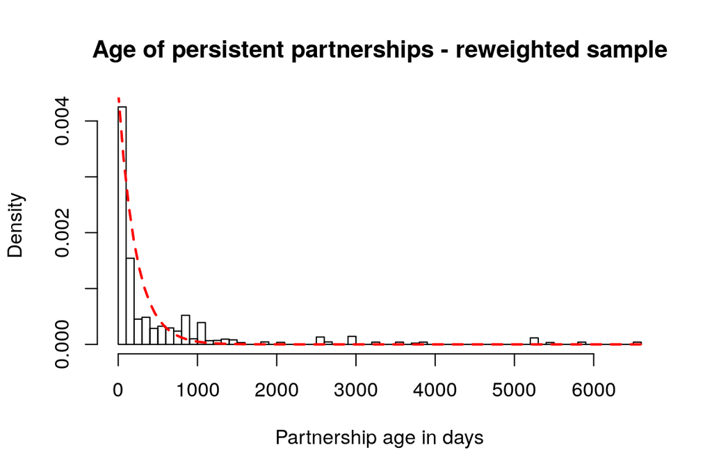

Assuming an exponential distribution, the mean duration of persistent partnerships given by the observed median duration of extant ties is shown in the table below.

| Observed median age in days | 153 |
| --- | --- |
| Calculated mean duration in days | 221 |